# Juvenile snowshoe hares at Bonanza Creek Experimental Forest: An exploratory report

Michelle Lepori-Bui

## Introduction

This report investigates juvenile snowshoe hare physical data from the University of Alaska Fairbanks Institute of Arctic Biology’s Long Term Ecological Research site, Bonanza Creek Experimental Forest. Snowshoe hares, *Lepus americanus*, are an important prey species in this forest, and trapping, measuring physical characteristics, and releasing them over time, can give us a lot of information about their populations. This report looks specifically at juvenile hares from three sites within the Bonanza Creek Experimental Forest and investigates comparisons and correlations between weight, sex, foot size, and sampling location.

## Exploratory findings

#### 1. Annual juvenile hare trap counts

In this section we count the total number of juvenile hare trappings during each year of the study in all grid sites.

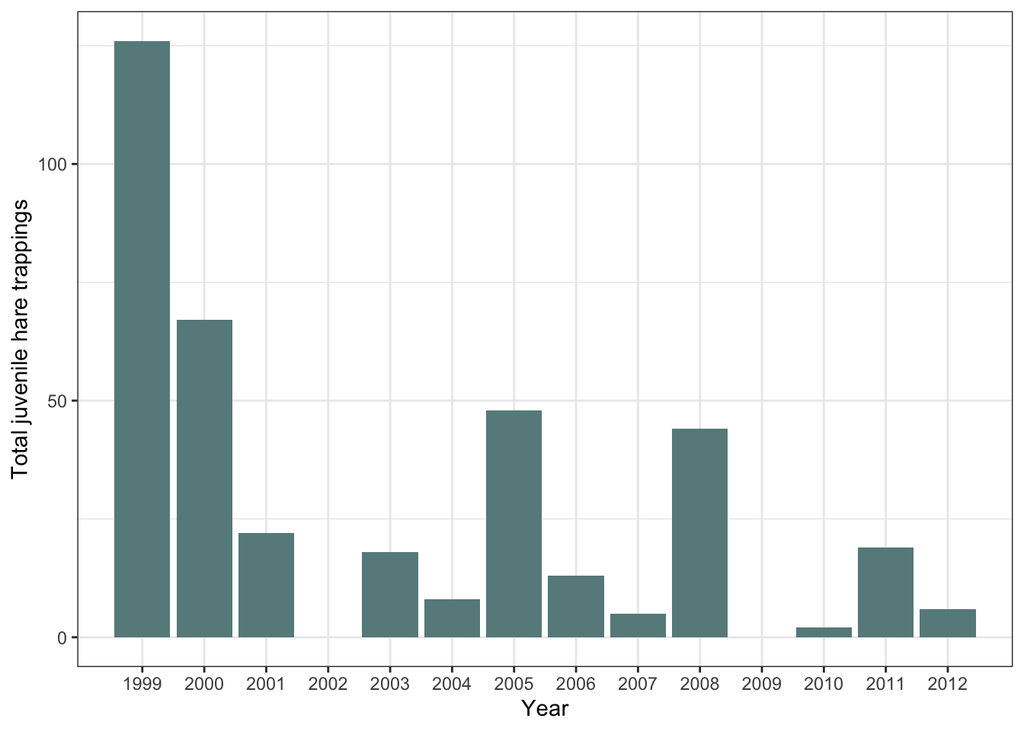

**Figure 1.** Total juvenile hare trappings per year at Bonanza Creek Experimental Forest from 1999 to 2012.

In general, the total number of juvenile hares trapped in Bonanza Creek Experimental Forest were highest at the beginning of the experiment in 1999, and declined in the years afters (Figure 1.). The most juvenile hares trapped in one year was 126, and the least (not including years where hares were trapped but no age information was recorded) was 2. The average number of juvenile hares trapped was 31.5, and the median 18.5. These counts include total juveniles trapped, but does not take into account trapping effort. In order to use this data to more confidently infer total hare population changes over time, it would be important take into account factors such as number of traps used, how many days per year were sampled, and time of year of sampling days.

### 2. Visualize juvenile hare weights

In this section we explore juvenile hare weights by sex and sampling location.

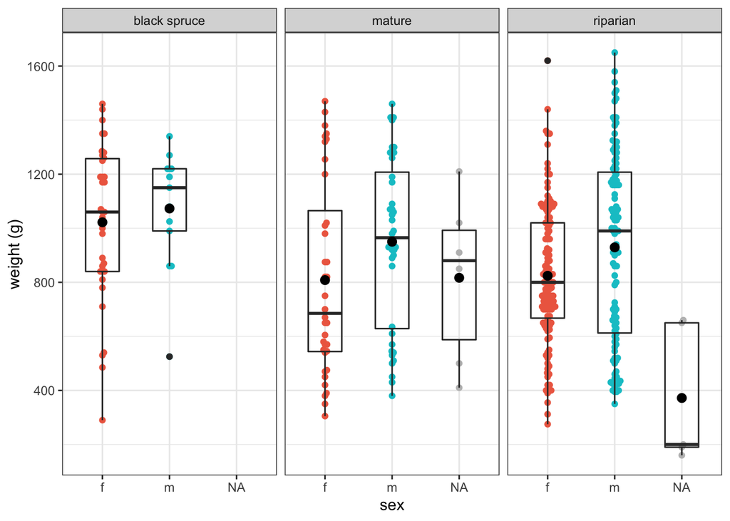

**Figure 2.** Juvenile snowshoe hare weights by sex (female, male, and not recorded) and site (black spruce, mature, and riparian) at Bonanza Creek Experimental Forest. Individual samples are represented by colored dots (female in coral, male in turquoise, and hares without recorded sex are in gray). Black boxes represent the 25<sup>th</sup> and 75<sup>th</sup> percentile, with medians depicted by the thicker black lines, and means depicted by black dots.

Overall, male juvenile snowshoe hares have higher mean and median weights than female juvenile hares at all three sampling locations. On average, both male and female hares sampled at in the black spruce site weighed more than in the mature and riparian sampling sites.

### 3. Juvenile weight comparison

In this section we take a closer look at the comparison of male and female juvenile hare weights.

**Table 1.** Summary statistics (mean, standard deviation, and sample size) of juvenile snowshoe hare weights by sex.

| Sex | Mean weight (g) | Standard deviation (g) | Sample size |
| --- | --- | --- | --- |
| f | 855.39 | 292.25 | 197 |
| m | 945.86 | 333.22 | 163 |

### 4. Relationship between juvenile weight and hind foot length

In this section we investigate the relationship between juvenile hare weight and hind foot length.

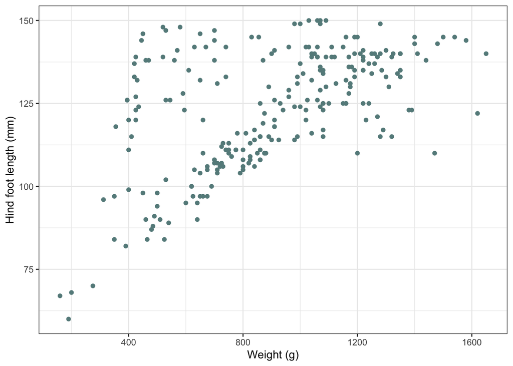

**Figure 3.** Relationship between weight (g) and hind foot length (mm) for all juvenile hares trapped at all sites.

Looking at the relationship of juvenile snowshoe hare weight and hind foot length (Figure 3.), some of the points do appear to have a relatively linear relationship, however there is a relatively large cluster of points that falls outside of this pattern. There is a moderate positive correlation (Pearson’s *r* = 0.55) and calculating a simple linear regression results in an average slope of $\beta$ = 9.52 and R<sup>2</sup> = 0.3. The diagnostic plots (not shown) of the linear model show that the residuals are not normally distributed nor homoscedastic, meaning the linear model may not be the best model to describe the data. Exploring the data a little more in depth reveals that the cluster of points that don’t fit the linear model all come from one site (riparian) in 1999 and 2000. It may be interesting to investigate these particular data further to see if anything may have impacted their weights or foot lengths at that site in those years causing them to not be predicted by the linear model.

### Citations

Kielland, K., F.S. Chapin, R.W. Ruess, and Bonanza Creek LTER. 2017. Snowshoe hare physical data in Bonanza Creek Experimental Forest: 1999-Present ver 22. Environmental Data Initiative. https://doi.org/10.6073/pasta/03dce4856d79b91557d8e6ce2cbcdc14